# Problema 1

July 18, 2016

```r
library(ggplot2)
library(dplyr)
ano.atual <- read.csv("~/Documents/workspace/AD1/problema1/dados/ano-atual.csv")
cota.estado <- read.csv("~/Documents/workspace/AD1/problema1/dados/valor-cota-por-estado.csv")
names(cota.estado) <- c("sgUF", "sum")
```

## Introdu????o

No problema 1 da disciplina An??lise de Dados 1 pede para ser feita uma an??lise sobre os dados coletados do site de transpar??ncia da c??mara dos deputados. Esses dados cont??m todos os gastos de nossos deputados em 2016 usando a sua cota para exerc??cio da atividade parlamentar. Nesse trabalho pretendo responder duas perguntar iniciais que levar??o ?? formula????o de mais duas perguntas.

## Pergunta 1: Levando em conta os gastos de janeiro a maio h?? alguma despesa que teve um aumento ou redu????o de gastos consider??vel durante esse per??odo?

#### Entendendo os dados

Os dados que iremos precisar aqui s??o os equivalentes aos 5 primeiros meses do ano, trabalhar s?? com esses meses ?? melhor pois ?? esperado que os valores declarados para esses meses, em sua maioria, j?? foram computados.

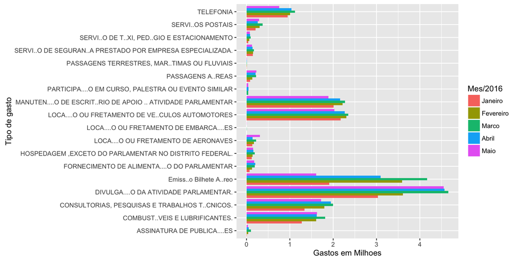

```r
##filtrando para ter s?? os 5 primeiros meses
trimestre1 = ano.atual %>% filter(numMes < 6)
## Agrupando por mes e por tipo de despesa, e somando todos os gastos.
tri.sum = trimestre1 %>% group_by(numMes, txtDescricao) %>% summarize(sum = sum(vlrDocumento))

##Mapeando os n??meros para o tipo de M??s.
tri.sum$numMes <- as.factor(tri.sum$numMes)
levels(tri.sum$numMes) <- c("Janeiro", "Fevereiro", "Marco", "Abril", "Maio")

ggplot(tri.sum,aes(x=factor(txtDescricao),y=sum/1000000, fill = factor(numMes))) +
  ylab("Gastos em Milhoes") + labs(x = "Tipo de gasto", fill = "Mes/2016") +
  geom_bar(position = "dodge", stat = "identity") +
  coord_flip()
```

Uma poss??vel explica????o para isso ?? que h?? algum tipo de gasto trismestral para a maioria dos deputados. Para investigarmos melhor vamos ver como a distribui????o Emiss??es de bilhetes a??reos, que teve muita redu????o, de Mar??o para Abril se comporta.

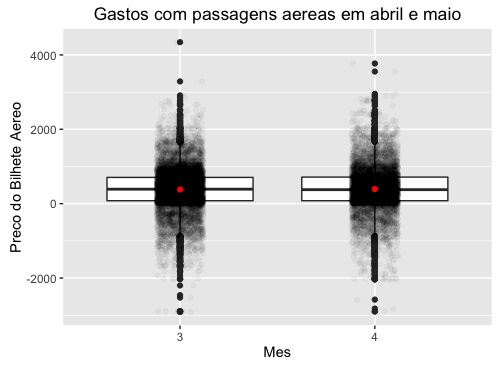

```r
gastosabrilmaio = ano.atual %>% filter((numMes == 4 | numMes == 3)
                                        & txtDescricao == "Emiss??o Bilhete A??reo")
medias = gastosabrilmaio %>%
  group_by(numMes) %>%
  summarise(vlrDocumento = mean(vlrDocumento))

ggplot(gastosabrilmaio, mapping = aes(x = as.factor(numMes), y = vlrDocumento) ) +
  labs( y ="Preco do Bilhete Aereo", x= "Mes",
        title = "Gastos com passagens aereas em abril e maio") +
  geom_boxplot() +
  geom_point(position = position_jitter(width = 0.3), alpha = 0.03) +
  geom_point(data = medias, colour = "red", size = 1.5)
```

```r
trimestre1 %>% count(numMes)
```

```
## # A tibble: 5 x 2
##   numMes     n
##    <int> <int>
## 1      1 19473
## 2      2 29340
## 3      3 35408
## 4      4 29380
## 5      5 24400
```

## Pergunta 2: Qual estado economiza mais em rela????o a sua cota?

Ainda considerando os primeiros 5 meses do ano, aqui est??o a m??dia de gastos dos primeiros 5 meses onde cada ponto representa 1 deputados e o ponto vermelho ?? a cota daquele deputado no m??s.

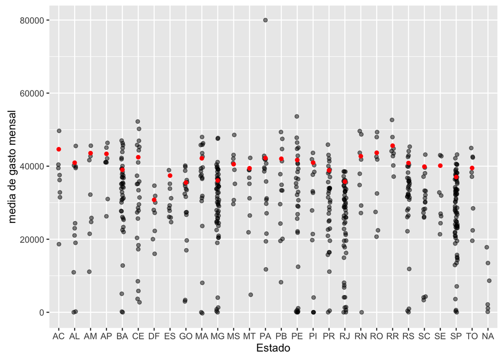

```r
## pergunta 2  Qual estado economiza mais em rela????o as cotas?
deputados = ano.atual %>% filter(numMes<6) %>%
  group_by(sgUF, txNomeParlamentar) %>% summarize(sum = sum(vlrDocumento)/5)

estados = deputados %>% group_by(sgUF) %>% summarise(mean = mean(sum))

ggplot(deputados, mapping = aes(x = sgUF, y = sum))+
  geom_point(position = position_jitter(width = 0.2), alpha = 0.5, na.rm = TRUE)+
  geom_point(data = cota.estado, colour = "red", size = 1.5)+
  labs( y ="media de gasto mensal", x= "Estado")
```

Algo interessante ?? que vemos alguns deputados que gastam mais que suas cotas mensais, isso ?? poss??vel? Mas enfim, vamos ver qual estado economiza mais, pegando a m??dia dos gastos dos deputados vamos ver qual est?? mais abaixo da cota

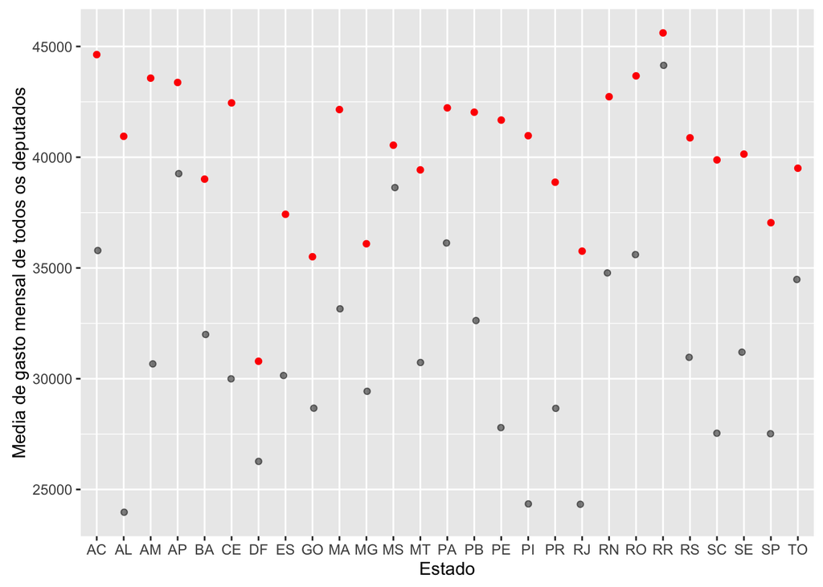

```r
estados = deputados %>% group_by(sgUF) %>% summarise(sum = mean(sum))
estados = estados %>% filter(sgUF != "")
ggplot(estados, mapping = aes(x = sgUF, y = sum))+
  geom_point(position = position_jitter(width = 0.2), alpha = 0.5, na.rm = TRUE)+
  geom_point(data = cota.estado, colour = "red", size = 1.5)+
  labs( y ="Media de gasto mensal de todos os deputados", x= "Estado")
```

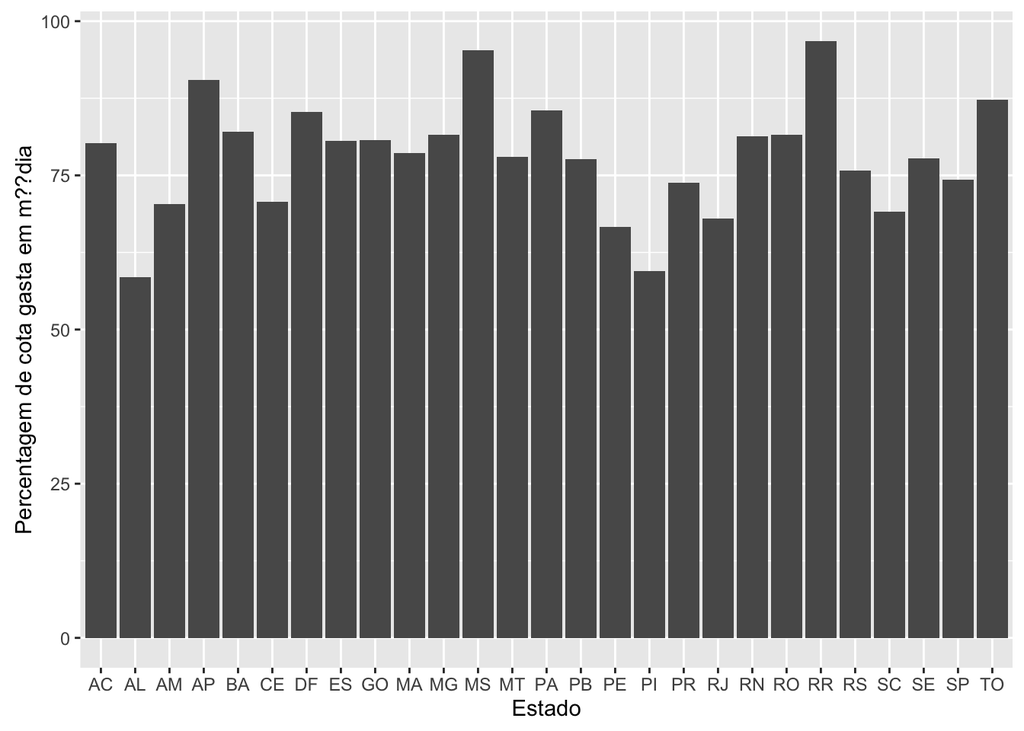

```r
estados$pc = estados$sum/cota.estado$sum*100
ggplot(estados, mapping = aes(x = sgUF, y = pc))+
  geom_bar(position = "dodge", stat = "identity")+
  labs( y ="Percentagem de cota gasta em m??dia", x= "Estado")
```

Assim vemos que Alagoas ?? o estado que tem os deputados que economizam mais. Ou ser?? os que trabalham menos?